# Acquisition Functions

Acquisition Functions (acq. functions) are used to find the *best* next possible point to sample when doing Bayesian Optimization. The term *best* in this context depends on what the user wants to achieve. In our case we want to find the most informative point so that our surrogate model (cf. **Bayesian Optimization**). In this notebook I will introduce three acq. functions. The first one is *Expected Improvement (EI)* which is commonly used and easy to implement. After that I will discuss *Mutual Information (MI)* and *Upper Confidence Bound (UCB)*.

## Exected Improvement

### Introduction

The *EI* function is a popular choice for an acquisition function since it combines probability and magnitude of the expected improvement (see https://arxiv.org/abs/1012.2599, Chapter 2.3.1) that a possible sample point yields. Note that in is original form this is a myopic (1-step ahaed) optimization which can be done recursively to obtain a multistep ahead optimization. Since this gets very expensive https://link.springer.com/article/10.1007/BF01099263 argued to use the following improvement function \begin{equation*} I(x) = \max(0,f_{t+1}(x)-f(x^+)) \end{equation*} where $f(x^+)$ is the best observed value so far. The improvement is either $0$ if the predicted value $f_{t+1}(x)$ is smaller than the best observed or the difference between the two. The new sample point is found by maximizing over all possible inputs given the already observed data $D_t = \{x_i,y_i\}$. \begin{equation*} x = \underset{x}{\mathrm{argmax}}\mathbb{E}(\max(0,f_{t+1}(x)-f(x^+))|D_t) \end{equation*} An analytical expression is derived by https://link.springer.com/article/10.1007/BF01099263 and https://arxiv.org/abs/1012.2599: \begin{equation*} EI (x) =\begin{cases} (\mu(x) - f(x^+))\Phi(Z)+\sigma(x)\phi(Z)), & \text{if $\sigma(x)>0$}\\ 0, & \text{if $\sigma(x)=0$} \end{cases} \end{equation*} where &\Phi(.)& and $\phi(.)$ denote the *CDF* and *PDF* respectively of the standard normal distribution. The term $Z$ abbreviates \begin{equation*} Z = \frac{\mu(x) - f(x^+)}{\sigma(x)} \end{equation*}

### Exploration vs Exploitation

The function can be extended to include a trade-off exploration vs exploitation by inserting an additional parameter $\zeta \geq 0$ into the equation \begin{equation*} EI (x) =\begin{cases} (\mu(x) - f(x^+) - \zeta)\Phi(Z)+\sigma(x)\phi(Z)), & \text{if $\sigma(x)>0$}\\ 0, & \text{if $\sigma(x)=0$} \end{cases} \end{equation*} and \begin{equation*} Z = \frac{\mu(x) - f(x^+) - \zeta}{\sigma(x)} \end{equation*} This enables the user to favour points that have a high surrogate mean (exploit) or high surogate variance (explore). Introducing this parameter changes $I(x)$ since the mean has to be higher the higher the value of $\zeta$. Therefore higher $\zeta$ lead to a more explorative behaviour and vice versa. https://dl.acm.org/citation.cfm?id=1626686 suggests a value of $\zeta = 0.01$ which works very well in a lot of cases. Suprisingly favouring exploration early and then decreasing the value $\zeta$ does not work well empirically and only slightly increases performance on short runs ($t < 30$).

The following code shows an implemtation of *EI* using *GPFlow* by creating a data set drawn from a kernel and then applying *EI* recursively for *10* runs.

```python
import gpflow
import numpy as np
import matplotlib
import math
import scipy.stats as ss
import matplotlib.pyplot as plt
%matplotlib inline
```

```python
fontsize_label = 24
fontsize_legend = 20
fontsize_ticks = 20
fontsize_title = 24
linewidth = 3
markeredgewidth = 3
markersize = 15
matplotlib.rcParams['figure.figsize'] = (16, 8)
```

```python
def plot2D(mean, var, *argv):
    '''
    Plot a 2D estimate based on a Gaussian Process estimate of some function f

    Mean and Variance of the prediction as well as a not known number of arrays is passed to this plotting function.
    Each array contains an object that is plotted.The array has to have the following structure:
    [xaxis, yaxis, "label", "marker"] where "marker" is an optional parameter

    For colors to work properly the following convention should be minded:
    1. Array is the ground trouth if known
    2. Array is the estimated mean
    3. Array is the estimated variance
    '''

    fig = plt.figure()
    for arg in argv:
        if len(arg) == 4:
            plt.plot(arg[0], arg[1], arg[3], mew=markeredgewidth, label=arg[2], lw=linewidth)
        else:
            plt.plot(arg[0], arg[1], mew=markeredgewidth, label=arg[2], lw=linewidth)
    # Plot variance
    if mean is not None and var is not None:
        plt.fill_between(X[:,0], mean[:,0] - 2*np.sqrt(var[:,0]), mean[:,0] + 2*np.sqrt(var[:,0]),
                     color='C1', alpha=0.2, label='Var($\hat{f(x)}$)')
    # Format plot
    plt.legend(prop={'size': fontsize_legend}, loc=4)
    plt.xlabel('x', fontsize=fontsize_label)
    plt.ylabel('f(x)', fontsize=fontsize_label)
    plt.xticks(fontsize=fontsize_ticks)
    plt.yticks(fontsize=fontsize_ticks)
    plt.grid()

def drawRandomFunction(k, X, num_Functions):
    K = k.compute_K_symm(X)
    return np.random.multivariate_normal(np.zeros(X.shape[0]), K, num_Functions).T

def plot_convergence(X_sample, Y_sample, num_init=2):
    plt.figure()

    # Exclude initial samples
    x = X_sample[num_init:].ravel()
    y = Y_sample[num_init:].ravel()
    r = range(1, len(x)+1)
    # Calculate distance between first selected point and the next one
    x_dist = [np.abs(a-b) for a, b in zip(x, x[1:])]
#     y_max_watermark = np.maximum.accumulate(y)

    plt.subplot(1, 2, 1)
    plt.plot(r[1:], x_dist, 'o-', lw=linewidth)
    plt.xlabel('Iteration', fontsize=fontsize_label)
    plt.ylabel('Distance', fontsize=fontsize_label)
    plt.xticks(fontsize=fontsize_ticks)
    plt.yticks(fontsize=fontsize_ticks)
    plt.title('Distance between consecutive x\'s', fontsize=fontsize_title)

#     plt.subplot(1, 2, 2)
#     plt.plot(r, y_max_watermark, 'ro-')
#     plt.xlabel('Iteration')
#     plt.ylabel('Best Y')
#     plt.title('Value of best selected sample')
```

```python
def get_EI(mu, var, f, zeta=0):
        """
        This function computes the expected improvement (EI) according to "A Tutorial on Bayesian Optimization of
        Expensive Cost Functions, with Application to Active User Modeling and Hierarchical Reinforcement Learning", by
        Eric Brochu, Vlad M. Cora, Nando de Freitas, URL: https://arxiv.org/abs/1012.2599.

        Parameters:
        mu: Mean
        var: Variance
        f: Observed values so far
        zeta: Exploitation vs exploration parameter, See reference for more information

        Return:
        EI at the submitted values
        """

#         print("f:" + str(f))
#         print("(mu - f - zeta): " + str((mu - f - zeta)))
#         print("np-max(.):" + str(np.max((mu - f - zeta))))
        delta = np.maximum(0, (np.subtract(mu,f) - zeta))
#         print("Delta: " + str(delta))
        sigma = np.sqrt(var)
#         print("Sigma: " + str(sigma))
        q = delta / sigma
#         print("Q: " + str(q))

        # Get cdf, pdf from scipy and compute EI
        cdf = ss.norm.cdf(q)
        pdf = ss.norm.pdf(q)
        ei = delta * cdf + sigma * pdf

        return ei
```

Now create a data set by drawing from a *RBF* kernel. After that *5* random points are chosen as trainig samples for a GP. The posterior together with the ground truth as well as the observed data points are marked to show how a GP posterior conditioned on randomly selected samples looks like.

```python
# Generate data
np.random.seed(9)
# Set some parameters
f = 0.5
N = 6.
lengthscale = 0.4
num_Functions = 1
num = 500
# Build data sets
X = np.linspace(0., N, num).reshape(num, 1)
k = gpflow.kernels.RBF(1, lengthscales=lengthscale)
Y_true = drawRandomFunction(k, X, num_Functions)

size = 5
np.random.seed(11)
index = np.random.choice(range(len(X)), size=size, replace=False)
X_sample = X[index]
Y_sample = Y_true[index]
```

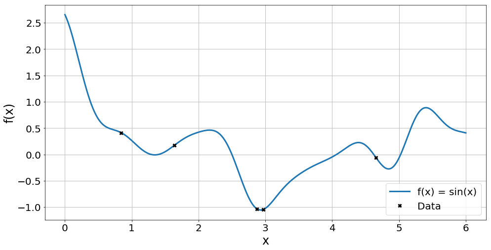

```python
# Plot ground truth and training set
fig = plot2D(None, None, [X, Y_true, 'f(x) = sin(x)'], [X_sample, Y_sample, 'Data', 'kx'])
```

```python
# Change noise parameter
sigma_n = 0.0
# Construct models with initial guess
k = gpflow.kernels.Matern52(1, lengthscales=0.3)
m = gpflow.models.GPR(X_sample, Y_sample, kern=k)
m.likelihood.variance = sigma_n
m.compile()
# Print out model
m
```

```
WARNING:gpflow.logdensities:Shape of x must be 2D at computation.
```

|  | class | prior | transform | trainable | shape | fixed_shape | value |
| --- | --- | --- | --- | --- | --- | --- | --- |
| GPR/kern/lengthscales | Parameter | None | +ve | True | () | True | 0.3 |
| GPR/kern/variance | Parameter | None | +ve | True | () | True | 1.0 |
| GPR/likelihood/variance | Parameter | None | +ve | True | () | True | 0.0 |

```python
gpflow.train.ScipyOptimizer().minimize(m)
m
```

```
INFO:tensorflow:Optimization terminated with:
  Message: b'CONVERGENCE: NORM_OF_PROJECTED_GRADIENT_<=_PGTOL'
  Objective function value: 1.504869
  Number of iterations: 8
  Number of functions evaluations: 12
```

[output not shown]

|  | class | prior | transform | trainable | shape | fixed_shape | value |
| --- | --- | --- | --- | --- | --- | --- | --- |
| GPR/kern/lengthscales | Parameter | None | +ve | True | () | True | 1.1299673533809915 |
| GPR/kern/variance | Parameter | None | +ve | True | () | True | 0.34380844449531206 |
| GPR/likelihood/variance | Parameter | None | +ve | True | () | True | 1.0000000002220446e-06 |

```python
# Predict with model
mean, var = m.predict_y(X)
```

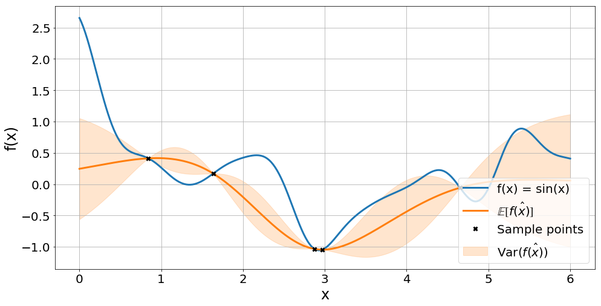

```python
# Plot posterior
fig = plot2D(mean, var, [X, Y_true, 'f(x) = sin(x)'], [X, mean, '$\mathbb{E[}\hat{f(x)}\mathbb{]}$'], [X_sample, Y_sample, 'Sample points', 'kx'])
```

Define a function to conveniently plot the ground truth, the observed data as well as mean, variance (posterior) and the acquisition function for given arguments. The function can also plot multiple acquisition functions to compare their choice of the next optimal point. After that plot the best possible choice for the next sample point according to *EI*.

```python
def plot_Acq(mean, var, X, Y_true, X_sample, data, mark_max=True, *argv):
    '''
    Function to plot ground truth, observed data as well as mean, variance (posterior) and
    the acquisition function for given arguments. The function will plot multiple acquisition functions in
    multiple subplot if receiving more than one array.

    Parameters:
    mean:     Mean of the posterior
    var:      Variance of the posterior
    X:        All possible inputs
    X_Sample: X-Coordinate of the observed data
    Data:     Value of the observed data
    mark_max: Whether or not to mark the best value according to the acq. function
    argv:     Array of acq. functions and their values as well as labels

    Return:
    -
    '''

    fig = plt.figure()
    ax = fig.add_subplot(len(argv)+1, 1, 1)
    ax.plot(X, Y_true, label='$f_{true}$', lw=linewidth)
    ax.plot(X, mean, label='$\mathbb{E[}\hat{f(x)}\mathbb{]}$', lw=linewidth)
    # Plot variance
    if mean is not None and var is not None:
        ax.fill_between(X[:,0], mean[:,0] - 2*np.sqrt(var[:,0]), mean[:,0] + 2*np.sqrt(var[:,0]),color='C1',
                        alpha=0.2, label='Var($\hat{f(x)}$)')
    ax.plot(X_sample, data, 'kx', label="Data", mew=markeredgewidth, lw=linewidth)

#     ax.set_xlim(left=np.min(X), right=np.max(X))
    plt.xticks(fontsize=fontsize_ticks)
    plt.yticks(fontsize=fontsize_ticks)
    plt.grid()
    plt.setp(ax.get_xticklabels(), visible=False)
    plt.ylabel('f(x)', fontsize=fontsize_label)
    plt.legend(prop={'size': fontsize_legend}, loc=4)

    for arg, index in zip(argv, range(len(argv))):

        ax = fig.add_subplot(len(argv)+1, 1, index+2, sharex=ax)
        ax.plot(arg[0], arg[1], mew=markeredgewidth, label=arg[2], lw=linewidth)
#         ax.set_xlim(left=np.min(X), right=np.max(X))
        if mark_max:
            ax.plot(X[np.argmax(arg[1])], arg[1][np.argmax(arg[1])], 'ro', mew=markeredgewidth, markersize=7)
        plt.xticks(fontsize=fontsize_ticks)
        plt.yticks(fontsize=fontsize_ticks)
        plt.legend(prop={'size': fontsize_legend}, loc=4)
        plt.xlabel('x', fontsize=fontsize_label)
        plt.ylabel('f(x)', fontsize=fontsize_label)
        plt.grid()
```

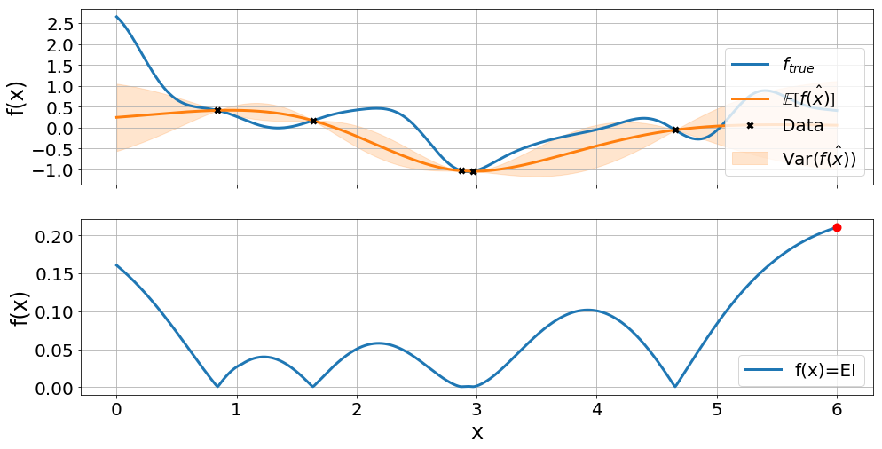

```python
ei = get_EI(mean, var, np.max(Y_sample), zeta=0.0)

plot_Acq(mean, var, X, Y_true, X_sample, Y_sample, True, [X, ei, 'f(x)=EI', False])
```

As you can see the expected improvement is zero at the already observed points sind we assume absence of noise in the observations. Also typical for *EI* is the choice of points on the borders of the input space. This intuitively is a waste of space since values outside the input space are usually less or not relevant for the task.

Now start with 2 inital points randomly chosen from a *RBF(l=0.4)* kernel as training set. After that optimize the hyperparameters according to the set, predict the posterior and use the predictions mean and variance to compute the best possible point according to *EI*. This is done recursively for $N=10$ times and output is plotted.

Note that optimization is done with regard to only the kernels variance. All the other parameters are fixed and also the the kernel the same kind as the ground truth.

```
WARNING:gpflow.logdensities:Shape of x must be 2D at computation.
```

```
INFO:tensorflow:Optimization terminated with:
  Message: b'CONVERGENCE: NORM_OF_PROJECTED_GRADIENT_<=_PGTOL'
  Objective function value: -0.041935
  Number of iterations: 5
  Number of functions evaluations: 10
```

[output not shown]

```
INFO:tensorflow:Optimization terminated with:
  Message: b'CONVERGENCE: NORM_OF_PROJECTED_GRADIENT_<=_PGTOL'
  Objective function value: 0.695505
  Number of iterations: 6
  Number of functions evaluations: 7
```

[output not shown]

```
INFO:tensorflow:Optimization terminated with:
  Message: b'CONVERGENCE: NORM_OF_PROJECTED_GRADIENT_<=_PGTOL'
  Objective function value: 1.019839
  Number of iterations: 3
  Number of functions evaluations: 5
```

[output not shown]

```
INFO:tensorflow:Optimization terminated with:
  Message: b'CONVERGENCE: NORM_OF_PROJECTED_GRADIENT_<=_PGTOL'
  Objective function value: 1.166303
  Number of iterations: 3
  Number of functions evaluations: 5
```

[output not shown]

```
INFO:tensorflow:Optimization terminated with:
  Message: b'CONVERGENCE: NORM_OF_PROJECTED_GRADIENT_<=_PGTOL'
  Objective function value: 9.169829
  Number of iterations: 10
  Number of functions evaluations: 11
```

[output not shown]

```
INFO:tensorflow:Optimization terminated with:
  Message: b'CONVERGENCE: NORM_OF_PROJECTED_GRADIENT_<=_PGTOL'
  Objective function value: 10.614191
  Number of iterations: 2
  Number of functions evaluations: 4
```

[output not shown]

```
INFO:tensorflow:Optimization terminated with:
  Message: b'CONVERGENCE: NORM_OF_PROJECTED_GRADIENT_<=_PGTOL'
  Objective function value: 11.541393
  Number of iterations: 4
  Number of functions evaluations: 6
```

[output not shown]

```
INFO:tensorflow:Optimization terminated with:
  Message: b'CONVERGENCE: NORM_OF_PROJECTED_GRADIENT_<=_PGTOL'
  Objective function value: 12.777250
  Number of iterations: 3
  Number of functions evaluations: 5
```

[output not shown]

```
INFO:tensorflow:Optimization terminated with:
  Message: b'CONVERGENCE: NORM_OF_PROJECTED_GRADIENT_<=_PGTOL'
  Objective function value: 13.645839
  Number of iterations: 4
  Number of functions evaluations: 6
```

[output not shown]

```
INFO:tensorflow:Optimization terminated with:
  Message: b'CONVERGENCE: NORM_OF_PROJECTED_GRADIENT_<=_PGTOL'
  Objective function value: 14.591129
  Number of iterations: 3
  Number of functions evaluations: 5
```

[output not shown]

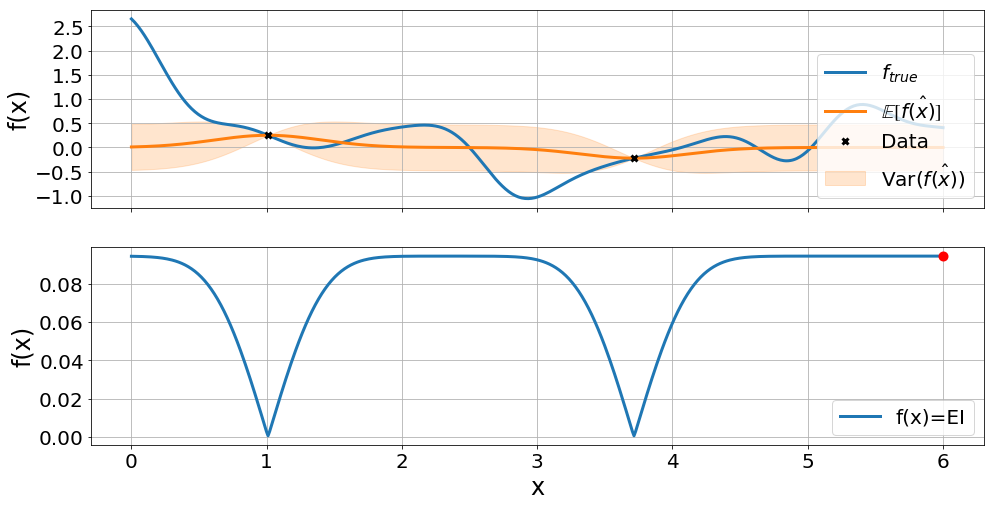

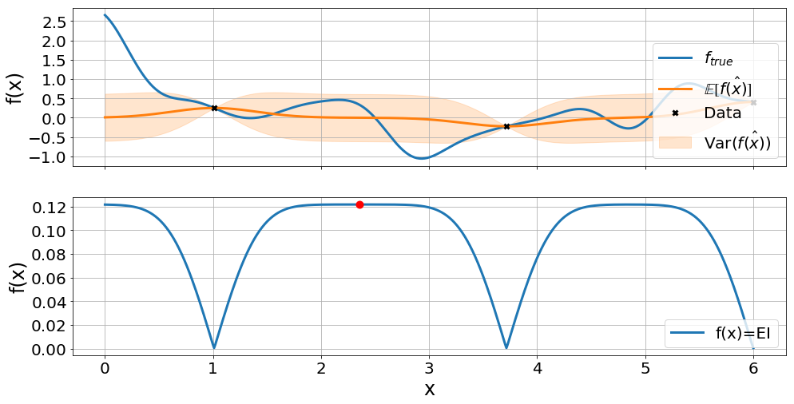

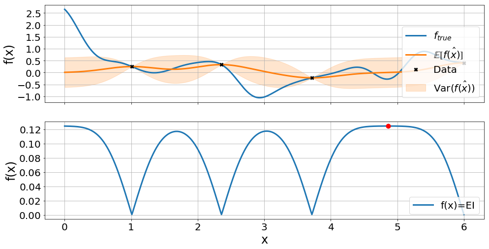

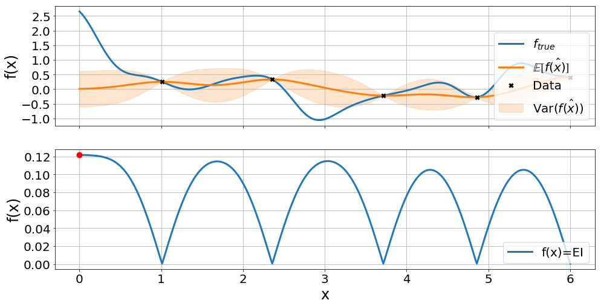

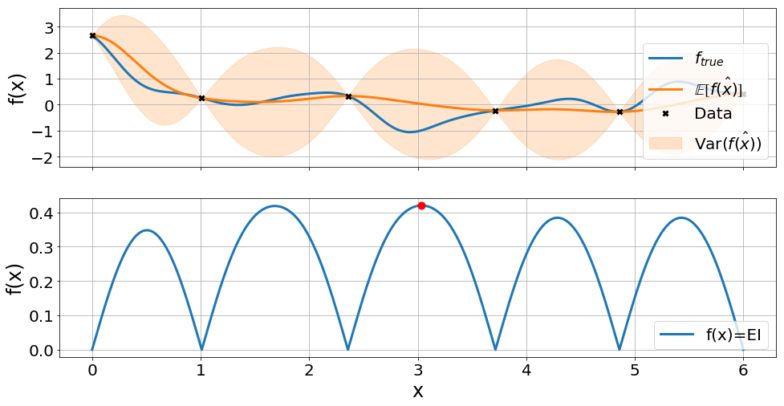

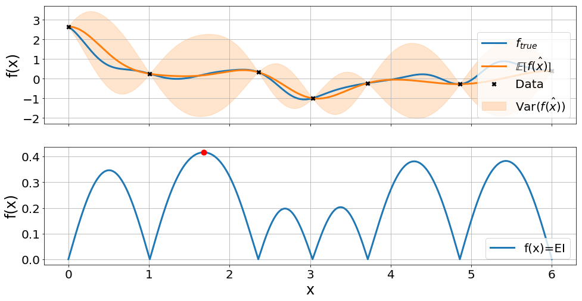

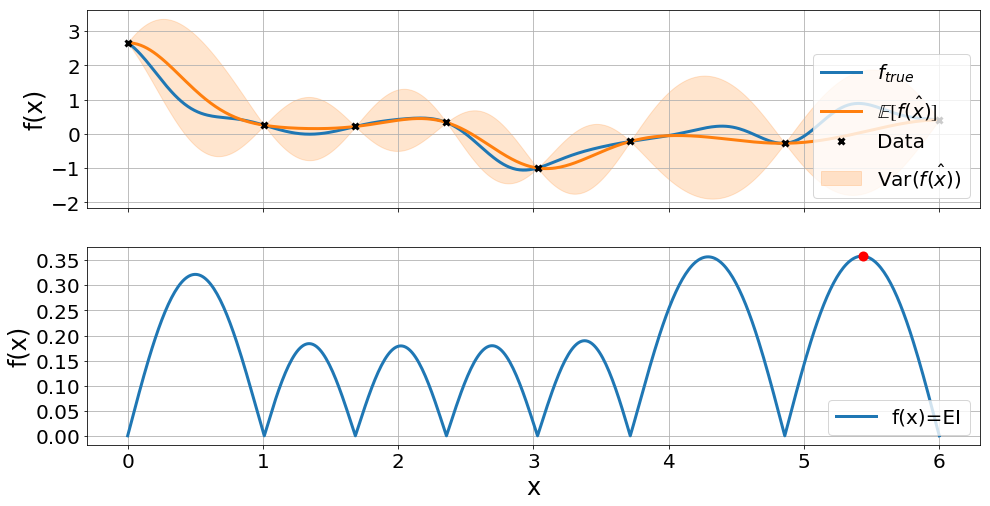

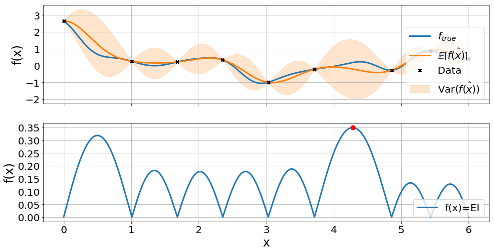

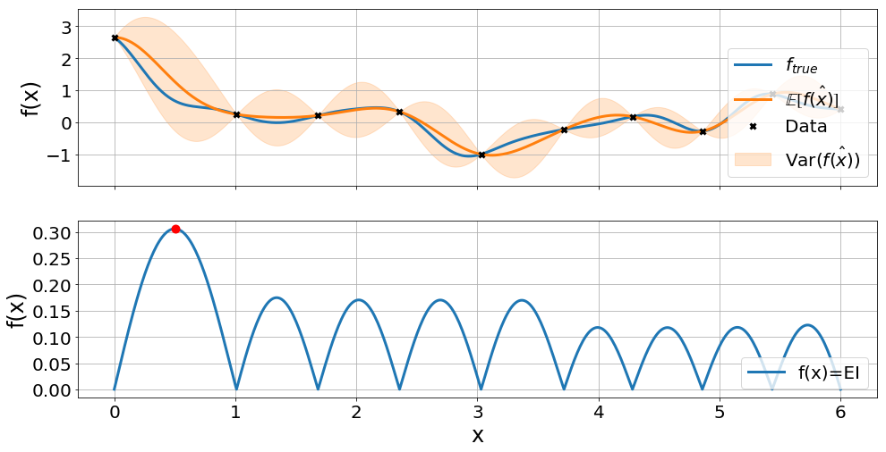

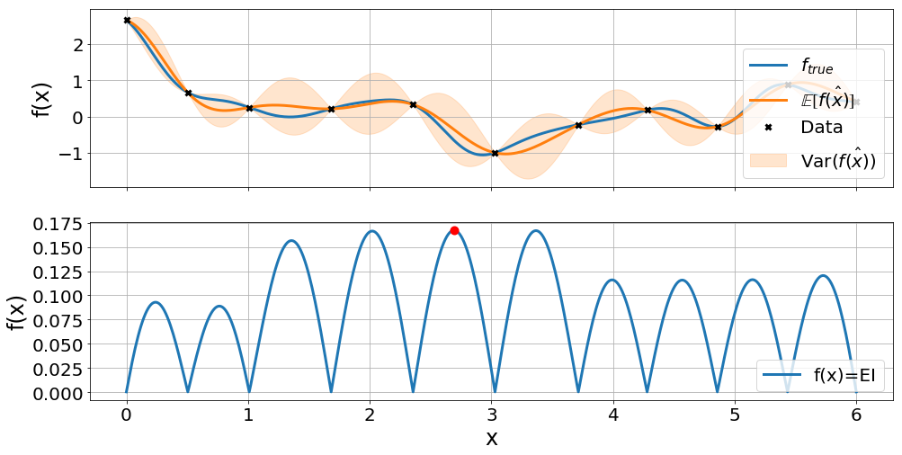

```python
# Set some parameters
k = gpflow.kernels.RBF(1, lengthscales=lengthscale)
N_samples = 10
sigma_n = 0.0

# Assume some initial samples
size = 2
np.random.seed(55)
index = np.random.choice(range(len(X)), size=size, replace=False)
X_sample = X[index]
Y_sample = Y_true[index]

# Compute EI
for i in range(N_samples):
    # Estimate model on samples
    m = gpflow.models.GPR(X_sample, Y_sample, kern=k)
    m.likelihood.variance = sigma_n
    m.kern.lengthscales.trainable = False
    m.likelihood.variance.trainable = False
    m.compile()
#     print(m)
    gpflow.train.ScipyOptimizer().minimize(m)

    # Predict with model
    mean, var = m.predict_y(X)

    # Calculate EI
    ei = get_EI(mean, var, np.max(Y_sample), zeta=0.0)

    # Plot
    plot_Acq(mean, var, X, Y_true, X_sample, Y_sample, True, [X, ei, 'f(x)=EI', False])

    # Append new point
    X_sample = np.append(X_sample, [X[np.argmax(ei)]], axis=0)
    Y_sample = np.append(Y_sample, [Y_true[np.argmax(ei)]], axis=0)
```

Usually, when used in the context of optimization this function should choose more points close to a local or global maximum and thus the distance should decrease. Also important is the already mentioned absence of noise which forces the GP to pass all observed data points which in real life scenarios is unrealistic.

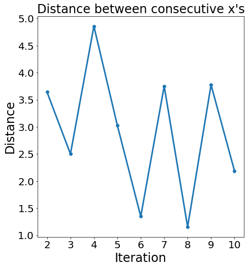

```python
plot_convergence(X_sample, Y_sample)
```

## Mutual Information

### Algorithm 1

```python
def get_MI(k,X, A, Sigma_y):

    mi = []

    for x, sigma_y in zip(X,Sigma_y):
        x = x.reshape(1,1)
        sigma_y = sigma_y.reshape(1,1)

        # Create A_bar according to paper, part 1: remove already chosen locations
        A_bar = np.delete(X,np.argwhere(A), axis=0)
        # Create A_bar according to paper, part 2: remove already chosen locations
        A_bar = np.delete(A_bar, np.argwhere(x), axis=0)
        dividend = np.matmul(k.compute_K(x,A), np.linalg.inv(k.compute_K_symm(A)))
        dividend = np.matmul(dividend,k.compute_K(A,x))

        dividend = sigma_y - dividend

        divisor = np.matmul(k.compute_K(x,A_bar), np.linalg.inv(k.compute_K_symm(A_bar)))
        divisor = np.matmul(divisor,k.compute_K(A_bar,x))
        divisor = sigma_y - divisor

        mi.append(np.divide(dividend,divisor)[0])

    mi = np.asarray(mi)

#     print('dividend.shape:' + str(dividend.shape))
#     print('divisor.shape:' + str(divisor.shape))
#     print('dividend:' + str(dividend))
#     print('divisor:' + str(divisor))
    return mi
```

```python
from pyitlib import discrete_random_variable as drv

drv.information_mutual(X)
```

[output not shown]

```
WARNING:gpflow.logdensities:Shape of x must be 2D at computation.
```

```
Iteration=0
```

```
WARNING:gpflow.logdensities:Shape of x must be 2D at computation.
```

```
Iteration=1
```

```
WARNING:gpflow.logdensities:Shape of x must be 2D at computation.
```

```
Iteration=2
```

```
WARNING:gpflow.logdensities:Shape of x must be 2D at computation.
```

```
Iteration=3
```

```
WARNING:gpflow.logdensities:Shape of x must be 2D at computation.
```

```
Iteration=4
```

```
WARNING:gpflow.logdensities:Shape of x must be 2D at computation.
```

```
Iteration=5
```

```
WARNING:gpflow.logdensities:Shape of x must be 2D at computation.
```

```
Iteration=6
```

```
WARNING:gpflow.logdensities:Shape of x must be 2D at computation.
```

```
Iteration=7
```

```
WARNING:gpflow.logdensities:Shape of x must be 2D at computation.
```

```
Iteration=8
```

```
WARNING:gpflow.logdensities:Shape of x must be 2D at computation.
```

```
Iteration=9
```

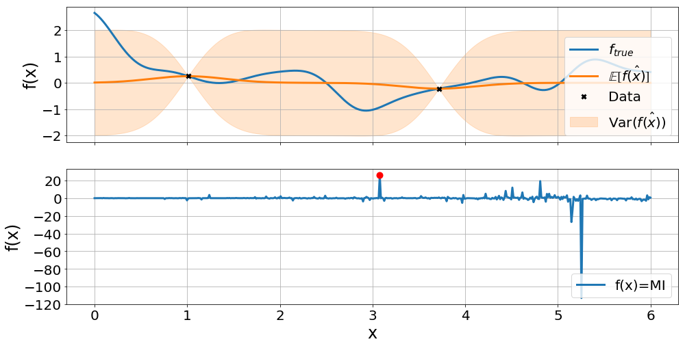

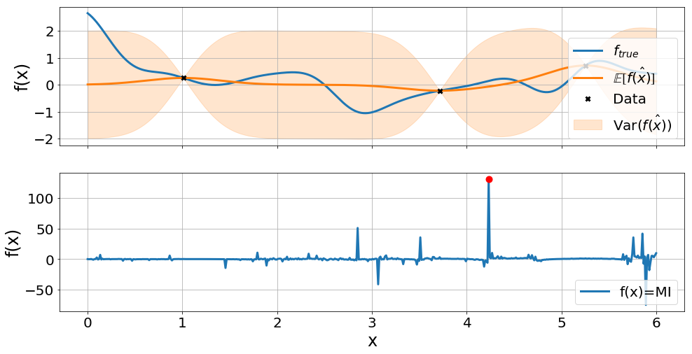

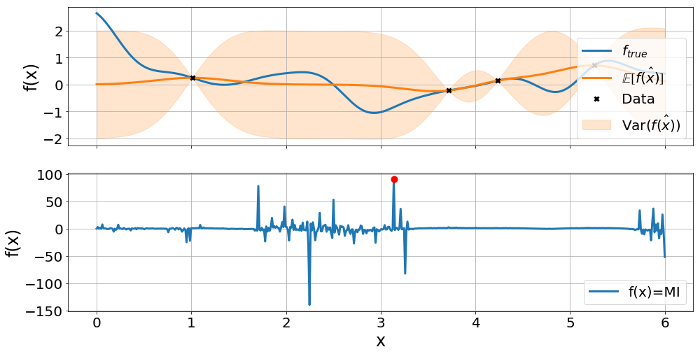

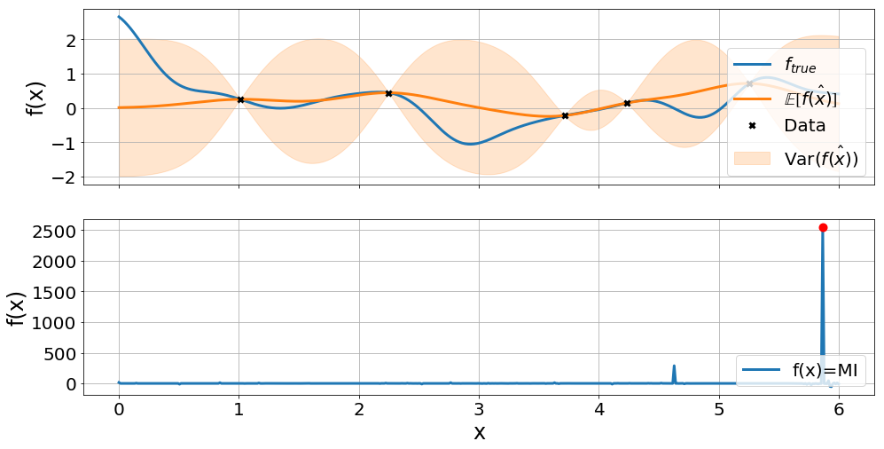

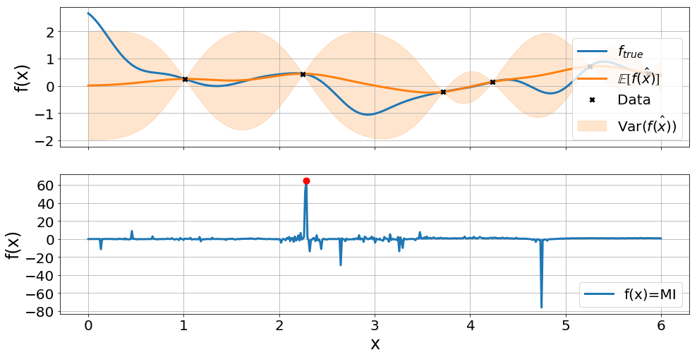

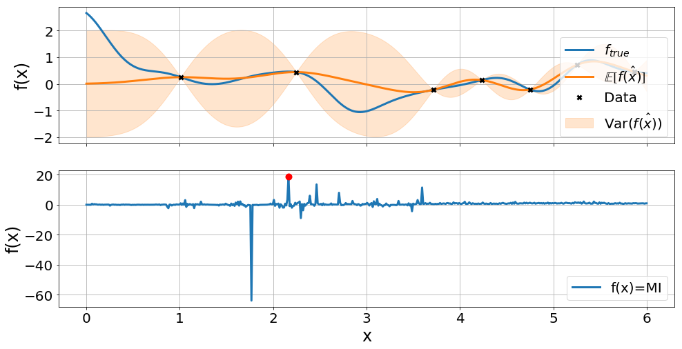

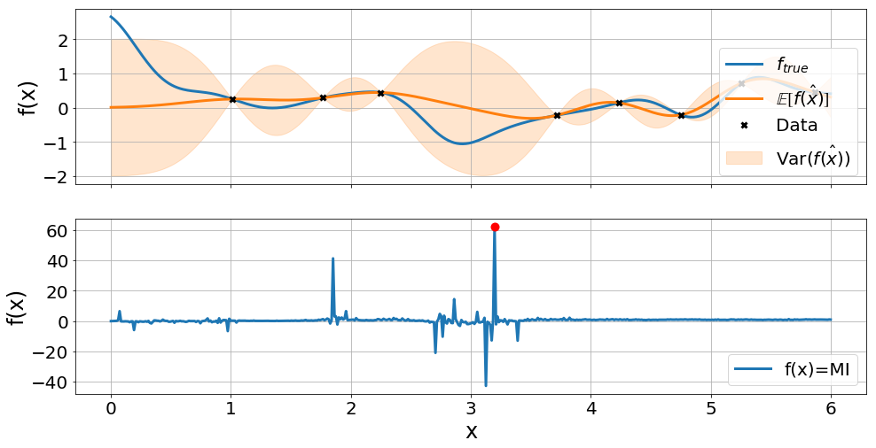

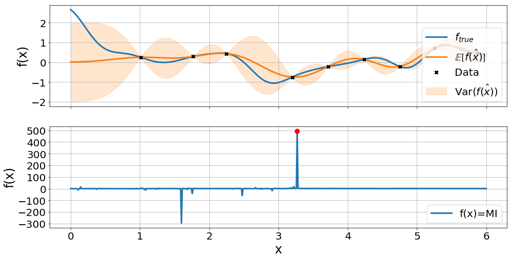

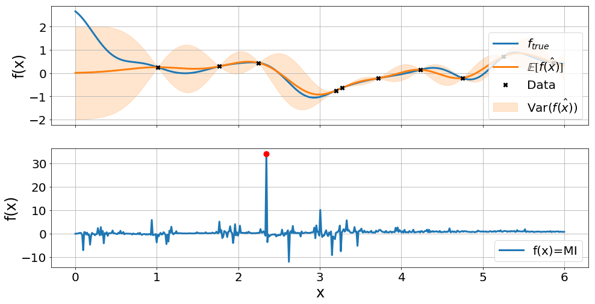

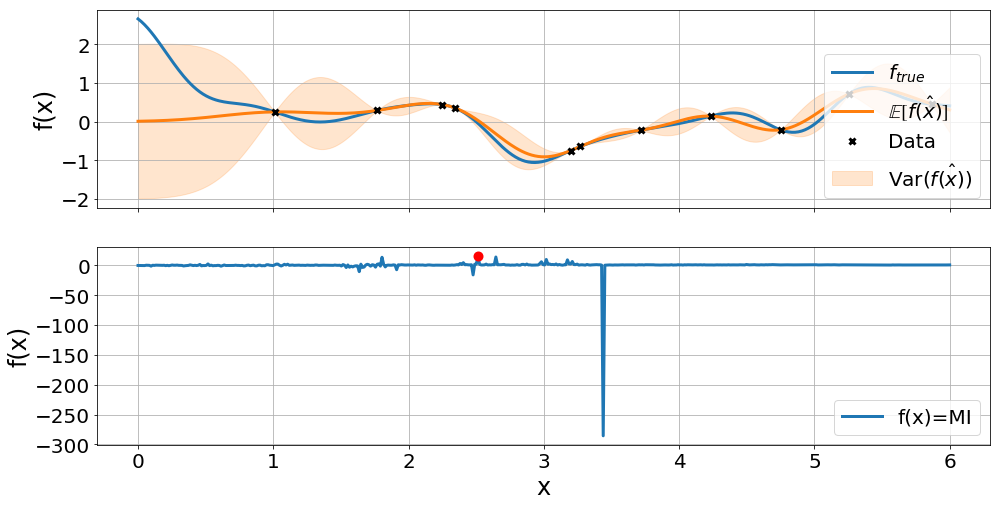

```python
# Set some parameters
k = gpflow.kernels.RBF(1, lengthscales=lengthscale)
N_samples = 10
sigma_n = 0.0

# Assume some initial samples
size = 2
np.random.seed(55)
index = np.random.choice(range(len(X)), size=size, replace=False)
X_sample = X[index]
Y_sample = Y_true[index]

for i in range(N_samples):
    print('Iteration=' + str(i))
    # Estimate model on samples
    m = gpflow.models.GPR(X_sample, Y_sample, kern=k)
    m.likelihood.variance = sigma_n
#     m.kern.lengthscales.trainable = False
#     m.likelihood.variance.trainable = False
    m.compile()
#     gpflow.train.ScipyOptimizer().minimize(m)

    # Predict with model
    mean, var = m.predict_y(X)

    # Calculate MI
    mi = get_MI(k=k, X=X, A=X_sample, Sigma_y=var)

    # Plot
    plot_Acq(mean, var, X, Y_true, X_sample, Y_sample, True, [X, mi, 'f(x)=MI', False])

    # Append new point
    X_sample = np.append(X_sample, [X[np.argmax(np.abs(mi))]], axis=0)
    Y_sample = np.append(Y_sample, [Y_true[np.argmax(np.abs(mi))]], axis=0)
```

## GP - UCB

Another possible acq. function is the so called *Gaussian Process upper confidence bound (GP-UCB)*. It results from the question: How can we learn an unknown function *f* as fast as possible? *Bayesian Experimental Design (ED)* can help us here since it uses the *informativeness* of a sample point by measuring its *information gain*. The possible sample point belongs to the set $\mathcal{A} \subseteq \mathcal{D}$ where $\mathcal{A}$ is the set of samples in the inputspace $\mathcal{D}$. The *information gain* is expressed trough the *Mutual Information* between the unknown function and the observations $y_A = f_A + \epsilon_A$ with $\epsilon \sim \mathcal{N}(0,I\sigma_n^2)$ at the sampling points in $\mathcal{A}$. *Mutual Information* is defined as \begin{equation*} I(y_\mathcal{A}, f) = H(y_\mathcal{A}) - H(y_\mathcal{A}|f) \end{equation*} where $H(.)$ is the entropy function. Optimizing this function for $\mathcal{A} \subset \mathcal{D}$ is NP-Hard and therefore approximated by an efficient greedy algorithm which maximizes \begin{equation*} x_t = \underset{x \in \mathcal{D}}{\mathrm{argmax}} \sigma_{t-1}(x) \end{equation*} Sequentaly optimizing this function is proven to be a good way to explore *f* but is not suited for optimization since it does not depend on observations made from the chosen sample points. A better strategy is to optimize \begin{equation*} x_t = \underset{x \in \mathcal{D}}{\mathrm{argmax}} \big( \mu_{t-1}(x) + \sqrt{\beta_t} \sigma_{t-1} \big) \end{equation*} for a finite set $\mathcal{D}$ $\beta_t$ is defined as \begin{equation*} \beta_t = 2 \log(|D|t^2\pi^2 / 6 \delta) \end{equation*} where delta is a value of $\delta = (0,1)$. One key fact of this function is that its error can be schon to bounded.  
For more information about the acq. function I'd like to refer to the following paper: Gaussian Process Optimization in the Bandit Setting: No Regret and Experimental Design (http://www-stat.wharton.upenn.edu/~skakade/papers/ml/bandit_GP_icml.pdf).

```python
def get_ucb(mu, var, beta_t):
    '''
    Implementation of the UCB acq. function according to
    http://www-stat.wharton.upenn.edu/~skakade/papers/ml/bandit_GP_icml.pdf.

    Parameters:
    mu: Mean
    var: Variance
    beta_t: Scalar to balance between exploration and exploitation

    Return:
    UCB at the submitted values
    '''
    return mu + np.sqrt(beta_t) * var
```